# lending_club

## Summary: Classifying bad loans with Lending Club loan data

The data are obtained from [Kaggle](https://www.kaggle.com/wendykan/lending-club-loan-data). The data can also be downloaded from the [Lending Club website](https://www.lendingclub.com/info/statistics.action). My objective is to classify whether a loan will become bad (i.e. late payments, charged off or defaulted) based on a borrower's personal characteristics. In this notebook,

1. Data preparation
   - I first check and transform the data to gather all the necessary predictors. There are nearly 150 indicators in the data set. Based on the descriptions, I select about 20 variables that I think can help to distinguish the bad loans from the good ones. These variables reflect, for example, the annual incomes, overall debts, purposes of borrowing, places of residence, etc.
1. Exploratory data analysis
   - Then, I do extensive exploratory data analyses that involve data visualization with matplotlib, seaborn and plotly
1. Classification models
   - For the classification of bad loans: I compare the performances of the models: Support Vector Machine, Logistic Regression, Decision Tree, Random Forest, AdaBoost with Decision Tree, Adaboost with Random Forest, and Extreme Gradient Boosting library XGBoost. Most models perform well, with high accuracy and recall scores.

## 1. Data wrangling

```python
import os
import json
import sqlite3
import numpy as np
import pandas as pd
import matplotlib.pyplot as plt
import seaborn as sns
import plotly.graph_objects as go
import plotly.express as px
from plotly.subplots import make_subplots
from pandas.io.json import json_normalize
from datetime import datetime

from sklearn import preprocessing
from sklearn.model_selection import train_test_split, StratifiedKFold, cross_val_score, StratifiedKFold
from sklearn.linear_model import SGDClassifier, SGDRegressor
from sklearn.naive_bayes import GaussianNB
from sklearn.metrics import plot_roc_curve, mean_squared_error, accuracy_score, make_scorer
from sklearn.ensemble import RandomForestClassifier, RandomForestRegressor, AdaBoostRegressor, AdaBoostClassifier
from sklearn.tree import DecisionTreeClassifier, DecisionTreeRegressor
from sklearn.decomposition import PCA

import xgboost as xgb
from imblearn.under_sampling import RandomUnderSampler

import warnings
warnings.filterwarnings('ignore')

sns.set()
pd.set_option('display.max_columns', None)

os.chdir("C:/Users/Nam/Desktop/Kaggle/lending_club")
```

#### Extract the selected predictors from the .sqlite data file

```python
l_var=['loan_status','loan_amnt','int_rate','annual_inc','emp_length','dti',\
        'purpose','grade','verification_status','hardship_reason','addr_state',\
        'avg_cur_bal','bc_util','delinq_2yrs','mort_acc',\
            'tot_cur_bal','total_pymnt','total_rec_int','issue_d']

conn=sqlite3.connect('database.sqlite')
c=conn.cursor()

command="SELECT {} FROM loan".format(','.join(i for i in l_var))
c.execute(command)

df=pd.DataFrame(c.fetchmany(500000), columns=l_var)

conn.close()
```

```python
l_cont=['loan_amnt','int_rate','annual_inc','dti','avg_cur_bal','bc_util','delinq_2yrs','mort_acc',\
        'tot_cur_bal','total_pymnt','total_rec_int']

df[l_cont]=df[l_cont].replace('',0).astype('float')
```

```python
df['date'] = pd.to_datetime(df['issue_d'])
df['month'] = df['date'].dt.month
df['year'] = df['date'].dt.year

emp=pd.Series(index=['10+ years', '6 years', '4 years', '< 1 year', '2 years',\
       '9 years', '5 years', '3 years', '7 years', '1 year',\
       '8 years','n/a'], data=[10,6,4,0.5,2,9,5,3,7,1,8,0])
df['emp_length']=df.emp_length.fillna('n/a').apply(lambda x: emp.loc[x])

# ['Current', 'Fully Paid', 'Late (31-120 days)', 'In Grace Period',
#        'Charged Off', 'Late (16-30 days)', 'Default',
#        'Does not meet the credit policy. Status:Fully Paid',
#        'Does not meet the credit policy. Status:Charged Off']
df['loan_type']=df['loan_status'].replace('Does not meet the credit policy. Status:Fully Paid','Fully Paid')\
                                    .apply(lambda x: 'Bad' if x not in ['Current','Fully Paid'] else x)
df['ratio_int_pymnt']=df['total_rec_int']/df['total_pymnt']

display(df.info())
```

```
<class 'pandas.core.frame.DataFrame'>
RangeIndex: 500000 entries, 0 to 499999
Data columns (total 24 columns):
loan_status            500000 non-null object
loan_amnt              500000 non-null float64
int_rate               500000 non-null float64
annual_inc             500000 non-null float64
emp_length             500000 non-null float64
dti                    500000 non-null float64
purpose                500000 non-null object
grade                  500000 non-null object
verification_status    500000 non-null object
hardship_reason        500000 non-null object
addr_state             500000 non-null object
avg_cur_bal            500000 non-null float64
bc_util                500000 non-null float64
delinq_2yrs            500000 non-null float64
mort_acc               500000 non-null float64
tot_cur_bal            500000 non-null float64
total_pymnt            500000 non-null float64
total_rec_int          500000 non-null float64
issue_d                500000 non-null object
date                   500000 non-null datetime64[ns]
month                  500000 non-null int64
year                   500000 non-null int64
loan_type              500000 non-null object
ratio_int_pymnt        499507 non-null float64
dtypes: datetime64[ns](1), float64(13), int64(2), object(8)
memory usage: 91.6+ MB
```

```
None
```

## 2. Exploratory data analysis

*Reminder*: **Bad loans** = late payments, charged off or defaulted

```python
def Cat_Plot(df, x, y, ax):
    by_x = pd.crosstab(df[y], df[x], normalize='index')*100
    by_x.plot(kind='bar', stacked=True, ax=ax)
    ax.set_ylabel('% of all loans by {}'.format(x))
    ax.legend(loc=[1.05,0])
    ax.tick_params(axis='x', rotation=0)

def Bar_Plot(df, x, y, estimator, ax, xlabel):
    sns.barplot(ax=ax, data=df, x=x, y=y, estimator=estimator)
    ax.set_xlabel(xlabel)

def Violin_Plot(df, x, y, ax, xlabel):
    sns.violinplot(ax=ax, data=df, x=x, y=y)
    ax.set_xlabel(xlabel)

def Box_Plot(df, x, y, ax, xlabel):
    sns.boxplot(ax=ax, data=df, x=x, y=y)
    ax.set_xlabel(xlabel)

def Scatter_Plot(df, x, y, hue, ax):
    sns.scatterplot(ax=ax, data=df, x=x, y=y, hue=hue)
```

### Loans by purpose and credit score

|  | count |
| --- | --- |
| Current | 439326 |
| Fully Paid | 42298 |
| Bad | 18376 |

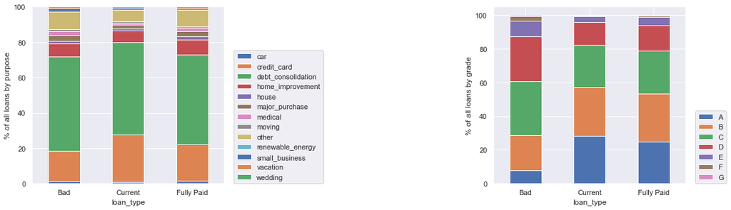

```python
y='loan_type'

display(df[y].value_counts().to_frame(name='count'))

fig=plt.figure(figsize=(18,5))
Cat_Plot(df, 'purpose', y, fig.add_subplot(131))
Cat_Plot(df, 'grade', y, fig.add_subplot(133))
fig.show()
```

### Loan amounts, incomes, debt ratios, and employment lengths per loan type

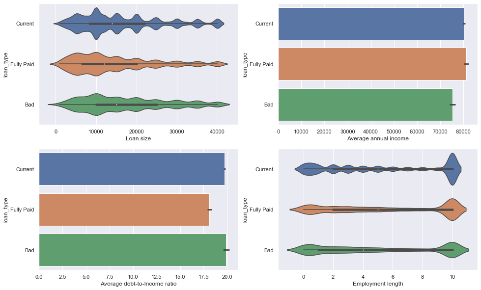

```python
fig=plt.figure(figsize=(16,10))
Violin_Plot(df, 'loan_amnt', y, fig.add_subplot(221), 'Loan size')
Bar_Plot(df, 'annual_inc', y, np.nanmean, fig.add_subplot(222), 'Average annual income')
Bar_Plot(df, 'dti', y, np.nanmean, fig.add_subplot(223), 'Average debt-to-Income ratio')
Violin_Plot(df, 'emp_length', y, fig.add_subplot(224), 'Employment length')
fig.show()
```

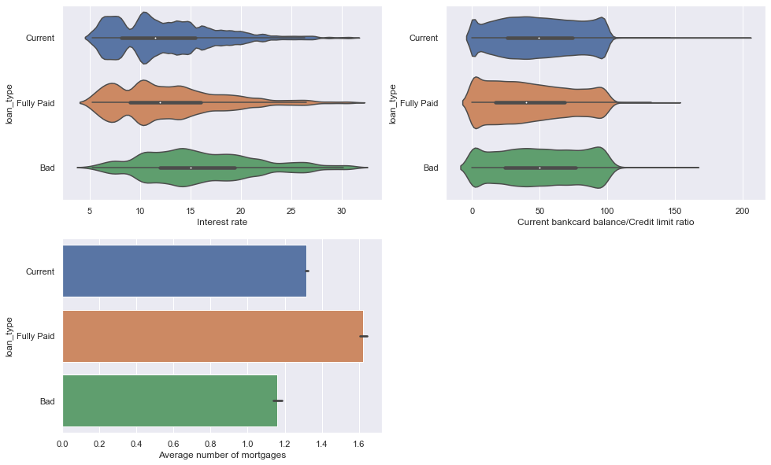

```python
fig=plt.figure(figsize=(16,10))
Violin_Plot(df, 'int_rate', y, fig.add_subplot(221), 'Interest rate')
Violin_Plot(df, 'bc_util', y, fig.add_subplot(222), 'Current bankcard balance/Credit limit ratio')
Bar_Plot(df, 'mort_acc', y, np.nanmean, fig.add_subplot(223), 'Average number of mortgages')
fig.show()
```

### Visualization with pairs of predictors

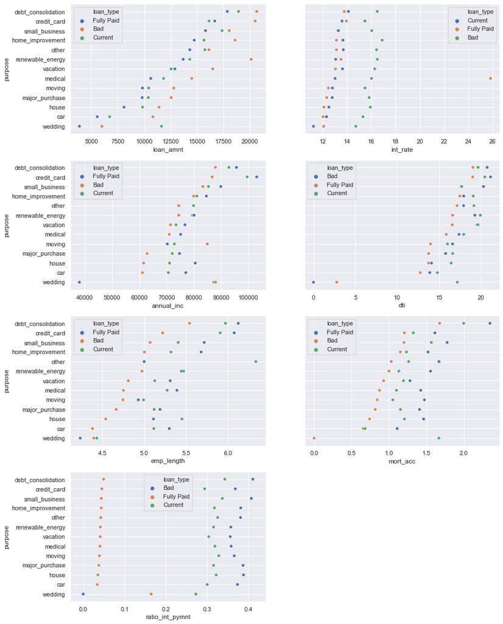

```python
Cat='purpose'

fig, ax=plt.subplots(4,2,figsize=(14,20), sharey=True)
for i,Var in enumerate(['loan_amnt', 'int_rate', 'annual_inc', 'dti', 'emp_length', 'mort_acc', 'ratio_int_pymnt']):
    Scatter_Plot(df.groupby([Cat, 'loan_type'])[Var].mean().reset_index().sort_values(by=Var),Var,Cat,'loan_type',ax[i//2,i%2])
fig.delaxes(ax[3,1])
fig.show()
```

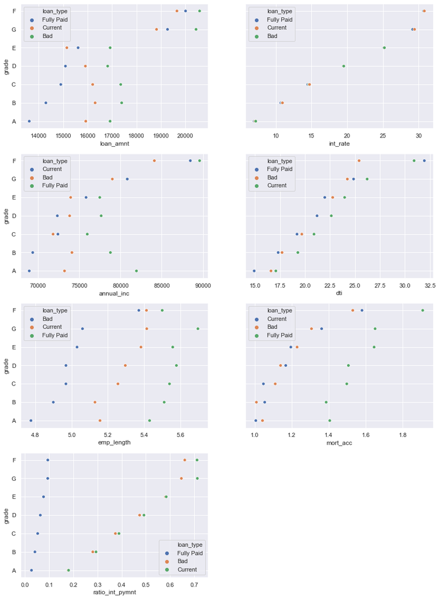

```python
Cat='grade'

fig, ax=plt.subplots(4,2,figsize=(14,20), sharey=True)
for i,Var in enumerate(['loan_amnt', 'int_rate', 'annual_inc', 'dti', 'emp_length', 'mort_acc', 'ratio_int_pymnt']):
    Scatter_Plot(df.groupby([Cat, 'loan_type'])[Var].mean().reset_index().sort_values(by=Var),Var,Cat,'loan_type',ax[i//2,i%2])
fig.delaxes(ax[3,1])
fig.show()
```

### Loans per location (US states)

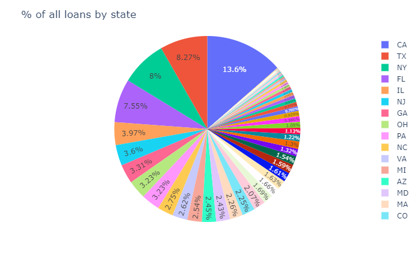

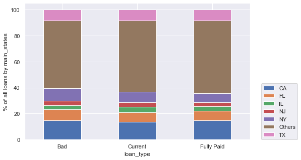

```python
Status=df.loan_status.unique()
Var='addr_state'

agg=df[df.loan_status.isin(Status)][Var].value_counts().reset_index().rename(columns={Var:'Number','index':Var})
fig=px.pie(agg[agg.Number>0], values='Number', names=Var).update_traces(textposition='inside')
fig.update_layout(width=600, title_text='% of all loans by state').show(renderer='png')

States= ['CA', 'TX', 'NY', 'FL', 'IL', 'NJ']
df['main_states']=df['addr_state'].apply(lambda x: x if x in States else 'Others')
fig, ax=plt.subplots(figsize=(8,5))
Cat_Plot(df, 'main_states', 'loan_type', ax)
fig.show()
```

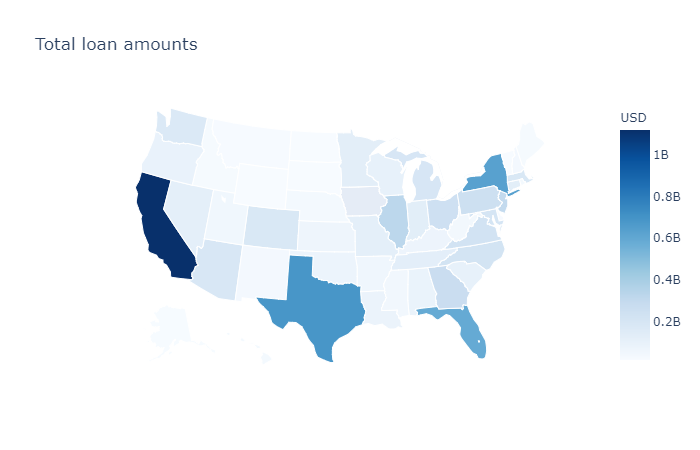

```python
def Map_Plot(df, GeoVar, ValVar, title, unit):
    fig = go.Figure(data=go.Choropleth(
        locations=df[GeoVar],
        z=df[ValVar].astype(float),
        locationmode='USA-states',
        colorscale='Blues',
        autocolorscale=False,
        text=df[GeoVar].astype('str')+'<br>'+df[ValVar].astype('str')+' '+unit,
        marker_line_color='white', # line markers between states
        colorbar_title=unit
    ))

    fig.update_layout(
        title_text=title,
        geo = dict(
            scope='usa',
            projection=go.layout.geo.Projection(type = 'albers usa'),
            showlakes=True, # lakes
            lakecolor='rgb(255, 255, 255)'),
    )
    return fig

bystate=df['loan_amnt'].groupby(df.addr_state).sum().reset_index()

fig = Map_Plot(bystate, 'addr_state', 'loan_amnt', 'Total loan amounts', 'USD')
fig.show(renderer='png')
```

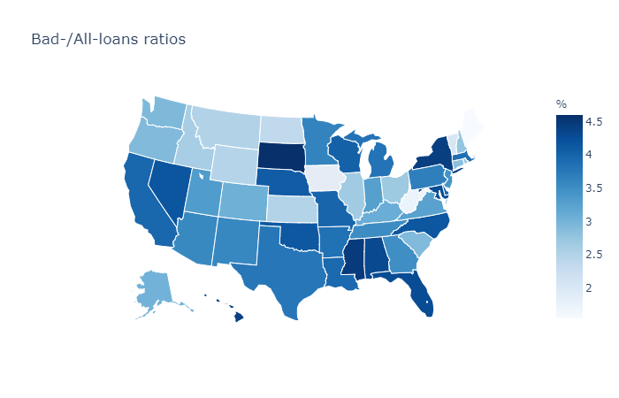

```python
bystate=(df.loan_type=='Bad').groupby(df.addr_state).sum()/df.addr_state.value_counts()*100
bystate=bystate.reset_index().rename(columns={'index':'addr_state',0:'badloan_ratios'})

fig = Map_Plot(bystate, 'addr_state', 'badloan_ratios', 'Bad-/All-loans ratios', '%')
fig.show(renderer='png')
```

## 3. Classification models

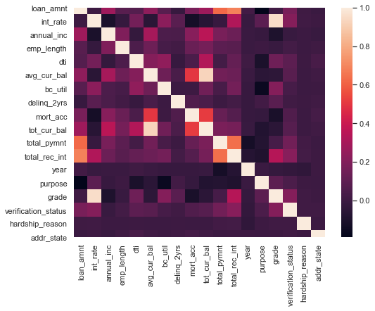

```python
l_cat=['purpose','grade','verification_status','hardship_reason','addr_state']
l_cont=['loan_amnt','int_rate','annual_inc','emp_length','dti',\
        'avg_cur_bal','bc_util','delinq_2yrs','mort_acc',\
            'tot_cur_bal','total_pymnt','total_rec_int','year']

df_sub=pd.DataFrame()
for col in l_cont:
    df_sub[col]=list(preprocessing.scale(df[col].apply(np.log).replace(-np.inf,0)))

# Transform categorical predictors into numerical
for col in l_cat:
    df_sub[col]=list(preprocessing.LabelEncoder().fit_transform(df[col].fillna('nan')))
df_sub['loan_type']=df['loan_type']

plt.figure(figsize=(8,6))
sns.heatmap(df_sub.corr())
plt.show()
```

### Visualization with principal components to quickly check the existence of clusters

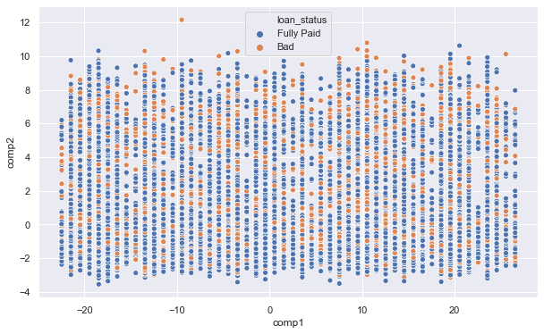

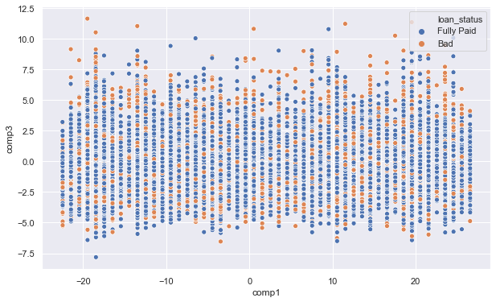

```python
# PCA
comp=pd.DataFrame(columns=['loan_status','comp1','comp2','comp3'])
comp['loan_status']=df['loan_type']
comp[['comp1','comp2','comp3']]=pd.DataFrame(PCA(n_components=3).fit_transform(df_sub[l_cat+l_cont].fillna(0)))

plt.figure(figsize=(10,6))
sns.scatterplot(data=comp[~comp.loan_status.isin(['Current'])], x='comp1', y='comp2', hue='loan_status')
plt.show()

plt.figure(figsize=(10,6))
sns.scatterplot(data=comp[~comp.loan_status.isin(['Current'])], x='comp1', y='comp3', hue='loan_status')
plt.show()
```

### All classification models

```python
models={'SVM':SGDClassifier(loss='hinge', max_iter=1000, tol=1e-3),\
        'Logit':SGDClassifier(loss='log', max_iter=1000, tol=1e-3),\
        'DT':DecisionTreeClassifier(max_depth=5),\
        'RF':RandomForestClassifier(max_depth=5,n_estimators=3),\
        'DT_Ada':AdaBoostClassifier(DecisionTreeClassifier(max_depth=5)),\
        'RF_Ada':AdaBoostClassifier(RandomForestClassifier(max_depth=5,n_estimators=3)),\
        'XGB':xgb.XGBClassifier(n_estimators=100)}
```

```python
def features_plot(ax, mod, l_names, title):
    if 'feature_importances_' in mod.__dir__():
        feature_weights=pd.Series(mod.feature_importances_, index=l_names).sort_values(ascending=False)
    else:
        feature_weights=pd.Series(mod.coef_[0], index=l_names).sort_values(ascending=False)
    sns.barplot(ax=ax, x=feature_weights.values, y=feature_weights.index).set_title(title)
```

### Feature importances

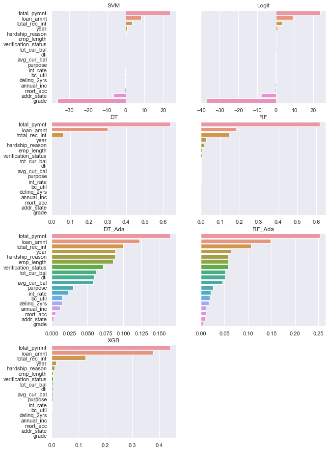

```python
X=np.array(df_sub[~df_sub.loan_type.isin(['Current'])][l_cat+l_cont].fillna(0))
y=np.array(df_sub[~df_sub.loan_type.isin(['Current'])]['loan_type']=='Bad')
X_train, X_test, y_train, y_test = train_test_split(X, y, test_size=0.2, random_state=0)

fig, ax=plt.subplots(4,2,figsize=(10,16), sharey=True)
for i, mod in enumerate(models.keys()):
    models[mod].fit(X_train, y_train)
    features_plot(ax[i//2,i%2], models[mod], l_cat+l_cont, mod)
fig.delaxes(ax[3,1])
fig.show()
```

### Recall scores: Bad loans vs. Good loans

```
Recall scores: Bad loans [0.9919743178170144, 0.9925093632958801, 0.9804708400214018, 0.9202782236490101, 0.9903691813804173, 0.9898341359015517, 0.9895666131621188]
Recall scores: Good (repaid) loans [1.0, 0.999523639395022, 0.999523639395022, 0.9915445992616411, 0.999761819697511, 0.9998809098487556, 1.0]
```

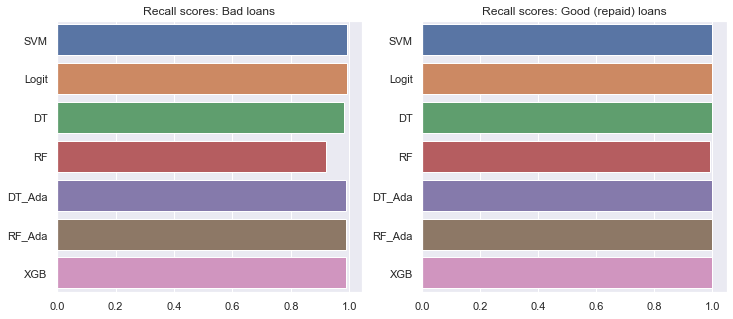

```python
def scores_plot(models, X, y, title, ax):
    scores=[accuracy_score(y, models[mod].predict(X)) for mod in models.keys()]
    sns.barplot(ax=ax, x=scores, y=list(models.keys())).set_title(title)
    print(title,scores)

X_pos=X_test[y_test>0,:]
y_pos=y_test[y_test>0]
X_neg=X_test[y_test==0,:]
y_neg=y_test[y_test==0]

fig, ax=plt.subplots(1,2,figsize=(12,5))
scores_plot(models, X_pos, y_pos, 'Recall scores: Bad loans', ax[0])
scores_plot(models, X_neg, y_neg, 'Recall scores: Good (repaid) loans', ax[1])
```

### Cross-validation

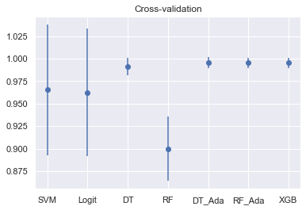

```python
NFold=5
scores=pd.DataFrame(index=range(NFold), columns=models.keys())

for mod in models.keys():
    scores[mod]=(cross_val_score(models[mod], X,y, scoring=make_scorer(accuracy_score), cv=NFold))

plt.figure()
plt.errorbar(x=scores.columns.values, y=scores.mean(), yerr=scores.std(), fmt='o')
plt.title('Cross-validation')
plt.show()
```

### Plotting ROC curves

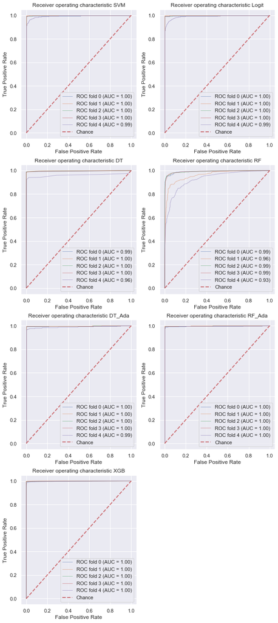

```python
def ROC_plot(classifier, cv, X, y, graph_title, ax):
    for i, (train, test) in enumerate(cv.split(X, y)):
        classifier.fit(X[train], y[train])
        plot_roc_curve(classifier, X[test], y[test],
                             name='ROC fold {}'.format(i),
                             alpha=0.5, lw=1, ax=ax)

    ax.plot([0, 1], [0, 1], linestyle='--', lw=2, color='r',
            label='Chance', alpha=.8)

    ax.set(xlim=[-0.05, 1.05], ylim=[-0.05, 1.05],
           title="Receiver operating characteristic {}".format(graph_title))
    ax.legend(loc="lower right")

cv = StratifiedKFold(n_splits=5)

fig, ax=plt.subplots(4,2,figsize=(10,24))
for i, mod in enumerate(models.keys()):
    ROC_plot(models[mod], cv, X, y, mod, ax[i//2,i%2])
fig.delaxes(ax[3,1])
fig.show()
```

### Cross-validation - Recall scores: Bad loans vs. Good loans

```
% of bad loans: 30.286448890793423
```

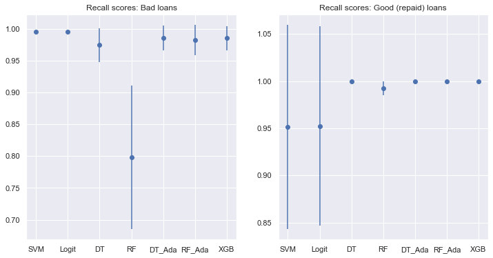

```python
X=np.array(df_sub[~df.loan_type.isin(['Current'])][l_cat+l_cont].fillna(0))
y=np.array(df_sub[~df_sub.loan_type.isin(['Current'])]['loan_type']=='Bad')

print('% of bad loans: {}'.format(np.nansum(y)/len(y)*100))

scores_positive=pd.DataFrame(index=range(5), columns=models.keys())
scores_negative=pd.DataFrame(index=range(5), columns=models.keys())

strkfold=StratifiedKFold(n_splits=5)
j=0
for i_train, i_test in strkfold.split(X,y):
    X_train, y_train = X[i_train,:], y[i_train]
    X_test, y_test = X[i_test,:], y[i_test]

    for mod in models.keys():
        models[mod].fit(X_train, y_train)

    X_pos=X_test[y_test>0,:]
    y_pos=y_test[y_test>0]
    X_neg=X_test[y_test==0,:]
    y_neg=y_test[y_test==0]

    scores_positive.loc[j]=[accuracy_score(y_pos, models[mod].predict(X_pos)) for mod in models.keys()]
    scores_negative.loc[j]=[accuracy_score(y_neg, models[mod].predict(X_neg)) for mod in models.keys()]
    j+=1

fig=plt.figure(figsize=(12,6))
fig.add_subplot(1,2,1)
plt.errorbar(x=scores_positive.columns.values, y=scores_positive.mean(), yerr=scores_positive.std(), fmt='o')
fig.add_subplot(1,2,2)
plt.errorbar(x=scores_negative.columns.values, y=scores_negative.mean(), yerr=scores_negative.std(), fmt='o')
fig.axes[0].set_title('Recall scores: Bad loans')
fig.axes[1].set_title('Recall scores: Good (repaid) loans')
plt.show()
```

### Check if we can predict which bad loan will default or get charged off:

This is just to try and see if we can differentiate the late payments from the defaulted or charged-off loans. The loans with late payments may eventually default or get charged off. Thus, these borrowers may not be that different from one another. The low performances of the classification models seem to confirm that the predictors do not distinguish well the two classes.

```
% of default/charged-off among the bad loans: 41.2059207662168
```

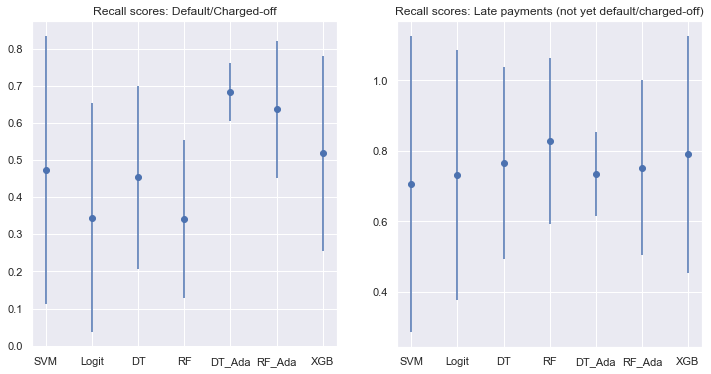

```python
X=np.array(df_sub[~df.loan_type.isin(['Current','Fully Paid'])][l_cat+l_cont].fillna(0))
y=np.array(df[~df_sub.loan_type.isin(['Current','Fully Paid'])]['loan_status'].isin(['Default','Charged Off','Does not meet the credit policy. Status:Charged Off']))

print('% of default/charged-off among the bad loans: {}'.format(np.sum(y)/len(y)*100))

scores_positive=pd.DataFrame(index=range(5), columns=models.keys())
scores_negative=pd.DataFrame(index=range(5), columns=models.keys())

strkfold=StratifiedKFold(n_splits=5)
j=0
for i_train, i_test in strkfold.split(X,y):
    X_train, y_train = X[i_train,:], y[i_train]
    X_test, y_test = X[i_test,:], y[i_test]

    for mod in models.keys():
        models[mod].fit(X_train, y_train)

    X_pos=X_test[y_test>0,:]
    y_pos=y_test[y_test>0]
    X_neg=X_test[y_test==0,:]
    y_neg=y_test[y_test==0]

    scores_positive.loc[j]=[accuracy_score(y_pos, models[mod].predict(X_pos)) for mod in models.keys()]
    scores_negative.loc[j]=[accuracy_score(y_neg, models[mod].predict(X_neg)) for mod in models.keys()]
    j+=1

fig=plt.figure(figsize=(12,6))
fig.add_subplot(1,2,1)
plt.errorbar(x=scores_positive.columns.values, y=scores_positive.mean(), yerr=scores_positive.std(), fmt='o')
fig.add_subplot(1,2,2)
plt.errorbar(x=scores_negative.columns.values, y=scores_negative.mean(), yerr=scores_negative.std(), fmt='o')
fig.axes[0].set_title('Recall scores: Default/Charged-off')
fig.axes[1].set_title('Recall scores: Late payments (not yet default/charged-off)')
plt.show()
```